# Introduction

## How to use the volkeR package?

First, load the package, set the plot theme and get some data.

```r
# Load the package
library(volker)

# Set the basic plot theme
theme_set(theme_vlkr())

# Load an example dataset ds from the package
ds <- volker::chatgpt
```

## How to generate tables and plots?

Decide whether your data is categorical or metric and choose the appropriate function:

- `report_counts()` shows frequency tables and generates simple and stacked bar charts.
- `report_metrics()` creates tables with distribution parameters, visualises distributions in density plots, box plots or scatter plots.

The column selection determines whether to analyse single variables, item lists or to compare and correlate multiple variables.

**Try out the following examples!**

### Categorical variables

```r
# A single variable
report_counts(ds, use_private)
```

```r
# A list of variables
report_counts(ds, c(use_private, use_work))
```

```r
# Variables matched by a pattern
report_counts(ds, starts_with("use_"))
```

### Metric variables

```r
# One metric variable
tab_metrics(ds, sd_age)
```

```r
# Multiple metric items
tab_metrics(ds, starts_with("cg_adoption_"))
```

### Cross tabulation and group comparison

Provide a grouping column in the third parameter to compare different groups.

```r
report_counts(ds, adopter, sd_gender)
```

For metric variables, you can compare the mean values. The ci parameter adds confidence intervals.

```r
report_metrics(ds, sd_age, sd_gender, ci = TRUE)
```

By default, the crossing variable is treated as categorical. You can change this behavior using the metric-parameter to calculate correlations:

```r
tab_metrics(ds, sd_age, use_work, metric = TRUE, ci = TRUE)
```

See the function help (F1 key) to learn the options. For example, you can use the `prop` parameter to grow bars to 100%. The `numbers` parameter prints frequencies and percentages onto the bars.

```r
ds |>
  filter(sd_gender != "diverse") |>
  report_counts(adopter, sd_gender, prop="rows", numbers= "n")
```

Further, the effect-functions conduct statistical tests:

```r
ds |>
  filter(sd_gender != "diverse") |>
  effect_counts(adopter, sd_gender)
```

## The volker report template

Reports combine plots, tables and effect calculations in an RMarkdown document. Optionally, for item batteries, an index, clusters or factors are calculated and reported.

To see an example or develop own reports, use the volker report template in RStudio:

- Create a new R Markdown document from the main menu
- In the popup select the “From Template” option
- Select the volker template.
- The template contains a working example. Just click knit to see the result.

Have fun with developing own reports!

Without the template, to generate a volker-report from any R-Markdown document, add `volker::html_report` to the output options of your Markdown document:

```
---
title: "How to create reports?"
output:
  volker::html_report
---
```

Then, you can generate combined outputs using the report-functions. One advantage of the report-functions is that plots are automatically scaled to fit the page. See the function help for further options (F1 key).

```r
ds %>%
  filter(sd_gender != "diverse") %>%
  report_metrics(starts_with("cg_adoption_"), sd_gender, box=TRUE, ci=TRUE)
```

#### Expectations

##### Plot

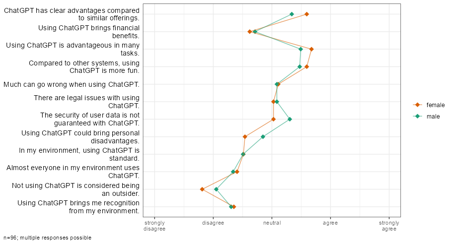

*4 missing case(s) omitted.*

##### Table

| Expectations | total | female | male |
| --- | --- | --- | --- |
| ChatGPT has clear advantages compared to similar offerings. | 3.4 (1.0) | 3.6 (1.0) | 3.3 (1.0) |
| Using ChatGPT brings financial benefits. | 2.7 (1.2) | 2.6 (1.2) | 2.7 (1.2) |
| Using ChatGPT is advantageous in many tasks. | 3.6 (1.1) | 3.7 (1.0) | 3.5 (1.1) |
| Compared to other systems, using ChatGPT is more fun. | 3.5 (1.0) | 3.6 (1.0) | 3.5 (1.0) |
| Much can go wrong when using ChatGPT. | 3.1 (1.1) | 3.1 (1.0) | 3.1 (1.2) |
| There are legal issues with using ChatGPT. | 3.1 (1.2) | 3.0 (1.0) | 3.1 (1.3) |
| The security of user data is not guaranteed with ChatGPT. | 3.2 (1.0) | 3.0 (1.0) | 3.3 (1.1) |
| Using ChatGPT could bring personal disadvantages. | 2.7 (1.1) | 2.5 (0.9) | 2.8 (1.2) |
| In my environment, using ChatGPT is standard. | 2.5 (1.1) | 2.5 (0.9) | 2.5 (1.3) |
| Almost everyone in my environment uses ChatGPT. | 2.4 (1.2) | 2.4 (1.0) | 2.3 (1.3) |
| Not using ChatGPT is considered being an outsider. | 2.0 (1.2) | 1.8 (1.0) | 2.1 (1.3) |
| Using ChatGPT brings me recognition from my environment. | 2.3 (1.2) | 2.4 (1.2) | 2.3 (1.3) |
| n | 96 | 37 | 59 |

*4 missing case(s) omitted.*

## Custom tab sheets

By default, a header and tabsheets are automatically created. You can mix in custom content.

- If you want to add content before the report outputs, set the title parameter to `FALSE` and add your own title.
- A good place for methodological details is a custom tabsheet next to the “Plot” and the “Table” buttons. You can add a tab by setting the close-parameter to `FALSE` and adding a new header on the fifth level (5 x # followed by the tab name). Close your custom new tabsheet with `#### {-}` (4 x #).

Try out the following pattern in an RMarkdown document!

````
#> ### Adoption types
#>
#> ```{r echo=FALSE}
#> ds %>%
#>   filter(sd_gender != "diverse") %>%
#>   report_counts(adopter, sd_gender, prop="rows", title=FALSE, close=FALSE)
#> ```
#>
#> ##### Method
#> Basis: Only male and female respondents.
#>
#> #### {-}
````

# Theming

The `theme_vlkr()`-function lets you customise colors:

```r
theme_set(theme_vlkr(
  base_fill = c("#F0983A","#3ABEF0","#95EF39","#E35FF5","#7A9B59"),
  base_gradient = c("#FAE2C4","#F0983A")
))
```

# Labeling

Labels used in plots and tables are stored in the comment attribute of the variable. You can inspect all labels using the `codebook()`-function:

```r
codebook(ds)
```

```
#> # A tibble: 94 × 6
#>    item_name     item_group item_class item_label         value_name value_label
#>    <chr>         <chr>      <chr>      <chr>              <chr>      <chr>
#>  1 case          case       numeric    case               <NA>       <NA>
#>  2 sd_age        sd         numeric    Age                <NA>       <NA>
#>  3 cg_activities cg         character  Activities with C… <NA>       <NA>
#>  4 adopter       adopter    factor     Innovator type     I try new… I try new …
#>  5 adopter       adopter    factor     Innovator type     I try new… I try new …
#>  6 adopter       adopter    factor     Innovator type     I wait un… I wait unt…
#>  7 adopter       adopter    factor     Innovator type     I only us… I only use…
#>  8 adopter       adopter    factor     Innovator type     [no answe… [no answer]
#>  9 sd_gender     sd         factor     Gender             female     female
#> 10 sd_gender     sd         factor     Gender             male       male
#> # ℹ 84 more rows
```

Set specific column labels by providing a named list to the items-parameter of `labs_apply()`:

```r
ds %>%
  labs_apply(
    items = list(
      "cg_adoption_advantage_01" = "Allgemeine Vorteile",
      "cg_adoption_advantage_02" = "Finanzielle Vorteile",
      "cg_adoption_advantage_03" = "Vorteile bei der Arbeit",
      "cg_adoption_advantage_04" = "Macht mehr Spaß"
    )
  ) %>%
  report_metrics(starts_with("cg_adoption_advantage_"))
```

Labels for values inside a column can be adjusted by providing a named list to the values-parameter of `labs_apply()`. In addition, select the columns where value labels should be changed:

```r
ds %>%
  labs_apply(
    cols=starts_with("cg_adoption"),
    values = list(
      "1" = "Stimme überhaupt nicht zu",
      "2" = "Stimme nicht zu",
      "3" = "Unentschieden",
      "4" = "Stimme zu",
      "5" =  "Stimme voll und ganz zu"
    )
  ) %>%
  report_metrics(starts_with("cg_adoption"))
```

To conveniently manage all labels of a dataset, save the result of `codebook()` to an Excel file, change the labels manually in a copy of the Excel file, and finally call `labs_apply()` with your revised codebook.

```r
library(readxl)
library(writexl)

# Save codebook to a file
codes <- codebook(ds)
write_xlsx(codes,"codebook.xlsx")

# Load and apply a codebook from a file
codes <- read_xlsx("codebook_revised.xlsx")
ds <- labs_apply(ds, codebook)
```

Be aware that some data operations such as `mutate()` from the tidyverse loose labels on their way. In this case, store the labels (in the codebook attribute of the data frame) before the operation and restore them afterwards:

```r
ds %>%
  labs_store() %>%
  mutate(sd_age = 2024 - sd_age) %>%
  labs_restore() %>%

  report_metrics(sd_age)
```

# Index calculation for item batteries

You can calculate mean indexes from a bunch of items using `add_index()`. A new column is created with the average value of all selected columns for each case. Provide a custom name for the column using the `newcol` parameter.

Reliability and number of items are calculated with `psych::alpha()` and stored as column attribute named “psych.alpha”. The reliability values are printed by `report`_metrics()`.

**Add a single index**

```r
ds %>%
  add_index(starts_with("cg_adoption_"), newcol = "idx_cg_adoption") %>%
  report_metrics(idx_cg_adoption)
```

**Compare the index values by group**

```r
ds %>%
  add_index(starts_with("cg_adoption_"), newcol = "idx_cg_adoption") %>%
  report_metrics(idx_cg_adoption, adopter)
```

**Add multiple indizes and summarize them**

```r
ds %>%
  add_index(starts_with("cg_adoption_")) %>%
  add_index(starts_with("cg_adoption_advantage")) %>%
  add_index(starts_with("cg_adoption_fearofuse")) %>%
  add_index(starts_with("cg_adoption_social")) %>%
  tab_metrics(starts_with("idx_cg_adoption"))
```

# Factor and cluster analysis

The easiest way to conduct factor analysis or cluster analyses is to use the respective parameters in the `report_metrics()` function.

```r
ds |>
  report_metrics(starts_with("cg_adoption"), factors = TRUE, clusters = TRUE)
```

Currently, cluster analysis is performed using kmeans and factor analysis is a principal component analysis. Setting the parameters to true, automatically generates scree plots and selects the number of factors or clusters. Alternatively, you can explicitly specify the numbers.

**Add factor analysis results**

If you want to work with the results, use `add_factors()` and `add_clusters()` respectively. For factor analysis, new columns prefixed with “fct_” are created to store the factor loadings based on the specified number of factors. For clustering, an additional column prefixed with “cls_” is added that assigns each observation to a cluster number. You can use the new columns as shown below.

```r
ds |>
  add_factors(starts_with("cg_adoption"), k = 3)  |>
  report_metrics(fct_cg_adoption_1, fct_cg_adoption_2, metric = TRUE)
```

**Automatically determine the number of factors**

To automatically determine the optimal number of factors or clusters based on diagnostics, set k = NULL.

```r
ds |>
  add_factors(starts_with("cg_adoption"), k = NULL) |>
  factor_tab(starts_with("fct_cg_adoption"))
```

**Compare values by cluster**

```r
ds |>
  add_clusters(starts_with("cg_adoption"), k = 3) |>
  report_counts(sd_gender, cls_cg_adoption, prop = "cols")
```

# What’s behind the scenes?

The volker-package is based on standard methods for data handling and visualisation. You could produce all outputs on your own. The package just makes your code dry - don’t repeat yourself - and wraps often used snippets into a simple interface.

Report functions call subsidiary tab and plot functions, which in turn call functions specifically designed for the provided column selection. In case you only need a table or want to work with the result of a table, call the specific function. For example `tab_counts()` or `plot_counts()`.

Console and markdown output is pimped by specific print- and knit-functions. To make this work, the cleaned data, produced plots, tables and markdown snippets gain new classes (`vlkr_df`, `vlkr_plt`, `vlkr_tbl`, `vlkr_list`, `vlkr_rprt`).

The volker-package makes use of common tidyverse functions. Basically, most outputs are generated by three functions:

- `count()` is used to produce counts
- `skim()` is used to produce metrics
- `ggplot()` is used to assemble plots.

Statistical tests, clustering and factor analysis are largely based on the stats, psych, car and effectsize packages.

Thanks to all the maintainers, authors and contributors of the packages that make the world of data a magical place.